# Análisis Exploratorio de los Datos GASTO SANITARIO

Alicia Perdices Guerra

17 de mayo, 2021

- **1.ANÁLISIS EXPLORATORIO POR PAISES.**
  - 1.1 EN RELACIÓN CON EL GASTO SANITARIO
    - 1.1.1 Análisis Descriptivo
    - 1.1.2 Visualización y Distribución de la variable “Value”
      - Sobre la información de la FINANCIACIÓN
      - Sobre la información del GASTO SANITARIO:
    - 1.1.3 Normalidad de la variable “Value”
      - Sobre la información de la FINANCIACIÓN
      - Sobre la información del GASTO SANITARIO:

#### **1.ANÁLISIS EXPLORATORIO POR PAISES**

Se procede en primer lugar a cargar todos los archivos para poder realizar el análisis.

```r
gasto_fin<-read.csv("C:/temp/GastoSanitario_Financiacion_clean.csv",sep= ",")
gasto_fun<-read.csv("C:/temp/GastoSanitario_Funcion_clean.csv",sep= ",")
gasto_pro<-read.csv("C:/temp/GastoSanitario_Proveedor_clean.csv",sep= ",")
ingresos<-read.csv("C:/temp/IngresosSanitarios_Financiacion_clean.csv",sep= ",")
medicos_p<-read.csv("C:/temp/Medicos_Por_Paises_clean.csv",sep= ",")
medicos_e<-read.csv("C:/temp/Medicos_x_especialidad_clean.csv",sep= ",")
enfermeria<-read.csv("C:/temp/Personal_Enfermeria_Cuidados_clean.csv",sep= ",")
perosnal_ne<-read.csv("C:/temp/PersonalSanitario_No_enfermeria_clean.csv",sep= ",")
personal<-read.csv("C:/temp/PersonalSanitarioHospitalario_clean.csv",sep= ",")
camas_p<-read.csv("C:/temp/Camas_Propiedad_clean.csv",sep= ",")
recursos_tec<-read.csv("C:/temp/RecursosTecnicos_hospitalarios_clean.csv",sep= ",")
tecnologia<-read.csv("C:/temp/TecnologiaMedica_clean.csv",sep= ",")
camas_t<-read.csv("C:/temp/TiposCamasHospitalarias_clean.csv",sep= ",")
deteccion_cu<-read.csv("C:/temp/Deteccion_Cancer_Mama_Cervix_clean.csv",sep= ",")
deteccion_ecd<-read.csv("C:/temp/Deteccion_enfCardio_Diabetes_clean.csv",sep= ",")
vacunacion<-read.csv("C:/temp/Vacunacion_+65_clean.csv",sep= ",")
estado<-read.csv("C:/temp/EstadoDeSalud_Sexo_clean.csv",sep= ",")
cuidados<-read.csv("C:/temp/CuidadosDomiciliarios_clean.csv",sep= ",")
mortalidad_tp<-read.csv("C:/temp/Mortalidad_Tratable_Prevenible_clean.csv",sep= ",")
mortalidad_ei<-read.csv("C:/temp/Muertes_Enf_Infecciosas_clean.csv",sep= ",")
altas_es<-read.csv("C:/temp/Altas_Estancias_CamasHospitalarias_clean.csv",sep= ",")
Ocupacion_cama<-read.csv("C:/temp/OcupacionCamaHospitalaria_clean.csv",sep= ",")
dia_tras<-read.csv("C:/temp/Pacientes_Dialisis_Trasplantes_clean.csv",sep= ",")
altas_hdd<-read.csv("C:/temp/RatioAltas_HospitalDia_Diagnostico_clean.csv",sep= ",")
```

**1.1.- EN RELACIÓN CON EL GASTO SANITARIO**

- **1.1.1 Análisis Descriptivo**

Se procede a realizar el análisis descriptivo:

```r
summary(gasto_fin)
```

```
##       TIME                          GEO                 UNIT
##  Min.   :2009   Austria               :  50   Million euro:2000
##  1st Qu.:2011   Belgium               :  50
##  Median :2014   Bosnia and Herzegovina:  50
##  Mean   :2014   Bulgaria              :  50
##  3rd Qu.:2016   Croatia               :  50
##  Max.   :2018   Cyprus                :  50
##                 (Other)               :1700
##                                                                                           ICHA11_HF
##  All financing schemes                                                                         :400
##  Compulsory contributory health insurance schemes and compulsory medical saving accounts (CMSA):400
##  Government schemes                                                                            :400
##  Government schemes and compulsory contributory health care financing schemes                  :400
##  Social health insurance schemes                                                               :400
##
##
##      Value         Value_imp
##  Min.   :      0   Mode :logical
##  1st Qu.:    996   FALSE:1487
##  Median :   8585   TRUE :513
##  Mean   : 153275
##  3rd Qu.:  69961
##  Max.   :1573543
##
```

```r
summary(gasto_fun)
```

```
##       TIME                          GEO                 UNIT
##  Min.   :2009   Austria               :  50   Million euro:2000
##  1st Qu.:2011   Belgium               :  50
##  Median :2014   Bosnia and Herzegovina:  50
##  Mean   :2014   Bulgaria              :  50
##  3rd Qu.:2016   Croatia               :  50
##  Max.   :2018   Cyprus                :  50
##                 (Other)               :1700
##                                       ICHA11_HC       Value
##  Curative care                             :400   Min.   :     70.5
##  Curative care and rehabilitative care     :400   1st Qu.:   1533.9
##  Current health care expenditure (CHE)     :400   Median :   9165.2
##  Inpatient curative and rehabilitative care:400   Mean   : 123048.4
##  Inpatient curative care                   :400   3rd Qu.:  41639.1
##                                                   Max.   :1573542.9
##
##  Value_imp
##  Mode :logical
##  FALSE:1405
##  TRUE :595
##
##
##
##
```

```r
summary(gasto_pro)
```

```
##       TIME                          GEO                 UNIT
##  Min.   :2009   Austria               :  50   Million euro:2000
##  1st Qu.:2011   Belgium               :  50
##  Median :2014   Bosnia and Herzegovina:  50
##  Mean   :2014   Bulgaria              :  50
##  3rd Qu.:2016   Croatia               :  50
##  Max.   :2018   Cyprus                :  50
##                 (Other)               :1700
##                                                       ICHA11_HP
##  All providers of health care                              :400
##  General hospitals                                         :400
##  Hospitals                                                 :400
##  Mental health hospitals                                   :400
##  Specialised hospitals (other than mental health hospitals):400
##
##
##      Value           Value_imp
##  Min.   :      0.0   Mode :logical
##  1st Qu.:    307.8   FALSE:1306
##  Median :   2031.6   TRUE :694
##  Mean   :  99226.2
##  3rd Qu.:  19879.7
##  Max.   :1573542.9
##
```

Se filta el dataframe para que la variable GEO aparezcan solo los paises objeto de estudio.(Para cada archivo relacionado con el Gasto Sanitario, y unificamos la información en una variable, gasto). Además se selecciona la información relevante de las variables ICHA11_HF,ICHA11_HC y ICHA11_HP:

```r
#En relación con la Financiación
#==============================
gasto_fin_paises<-gasto_fin[((gasto_fin$GEO!="European Union - 27 countries (from 2020)")&
                              +(gasto_fin$GEO!="European Union - 28 countries (2013-2020)")&
                              +(gasto_fin$GEO!="European Union - 27 countries (2007-2013)")&
                              +(gasto_fin$GEO!="European Union - 15 countries (1995-2004)")&
                              +(gasto_fin$GEO!="Euro area - 12 countries (2001-2006)")&
                              +(gasto_fin$GEO!="Euro area - 19 countries  (from 2015)")&
                              +(gasto_fin$GEO!="Euro area - 18 countries (2014)")&
                              +(gasto_fin$GEO!="Euro area - 12 countries (2001-2006)")),]
# Toda la financiación en conjunto
gasto_fin_paises<-
  gasto_fin_paises[(gasto_fin$ICHA11_HF=="All financing schemes"),]

#Se han creado registros con valores NA en el proceso de eliminación de
#factores GEO e ICHA11_HF . Se eliminan
idx=which(is.na(gasto_fin_paises))
gasto_fin_paises=gasto_fin_paises[-c(idx),]

#En relación con la Función.
#==============================
gasto_fun_paises<-gasto_fun[(gasto_fun$GEO!="European Union - 27 countries (from 2020)")&
                              +(gasto_fun$GEO!="European Union - 28 countries (2013-2020)")&
                              +(gasto_fun$GEO!="European Union - 27 countries (2007-2013)")&
                              +(gasto_fun$GEO!="European Union - 15 countries (1995-2004)")&
                              +(gasto_fun$GEO!="Euro area - 19 countries  (from 2015)")&
                              +(gasto_fun$GEO!="Euro area - 18 countries (2014)")&
                              +(gasto_fun$GEO!="Euro area - 12 countries (2001-2006)"),]
#Se selecciona todo lo relacionado con el gasto
#en Cuidados Curativos y de Rehabilitación en general y en pacientes ingresados.
gasto_fun_paises_cr_care<-
  gasto_fun_paises[(gasto_fun$ICHA11_HC=="Curative care and rehabilitative care"),]
gasto_fun_paises_ip_cr_care<-
  gasto_fun_paises[(gasto_fun$ICHA11_HC=="Inpatient curative and rehabilitative care"),]

#Se han creado registros con valores NA en el proceso de eliminación de
#factores GEO e ICHA11_HC . Se eliminan
idx=which(is.na(gasto_fun_paises_cr_care))
gasto_fun_paises_cr_care=gasto_fun_paises_cr_care[-c(idx),]

idx=which(is.na(gasto_fun_paises_ip_cr_care))
gasto_fun_paises_ip_cr_care=gasto_fun_paises_ip_cr_care[-c(idx),]


#En relación con el Proveedor.
#==============================
gasto_pro_paises<-gasto_pro[(gasto_pro$GEO!="European Union - 27 countries (from 2020)")&
                              +(gasto_pro$GEO!="European Union - 28 countries (2013-2020)")&
                              +(gasto_pro$GEO!="European Union - 27 countries (2007-2013)")&
                              +(gasto_pro$GEO!="Euro area - 19 countries  (from 2015)")&
                              +(gasto_pro$GEO!="European Union - 15 countries (1995-2004)")&
                              +(gasto_pro$GEO!="Euro area - 18 countries (2014)")&
                              +(gasto_pro$GEO!="Euro area - 12 countries (2001-2006)"),]

#Se selecciona información sobre el gasto sanitario destinado a:
#Hospitales, Hospitales mentales, y Hospitales Especiales.
gasto_pro_paises_hospital<-
gasto_pro_paises[(gasto_pro$ICHA11_HP=="Hospitals"),]
gasto_pro_paises_mental_hospital<-
gasto_pro_paises[(gasto_pro$ICHA11_HP=="Mental health hospitals"),]
gasto_pro_paises_specialised_hospital<-
gasto_pro_paises[(gasto_pro$ICHA11_HP=="Specialised hospitals (other than mental health hospitals)"),]

#Se han creado registros con valores NA en el proceso de eliminación de
#factores GEO e ICHA11_HP. Se eliminan
idx=which(is.na(gasto_pro_paises_hospital))
gasto_pro_paises_hospital=gasto_pro_paises_hospital[-c(idx),]


idx=which(is.na(gasto_pro_paises_mental_hospital))
gasto_pro_paises_mental_hospital=gasto_pro_paises_mental_hospital[-c(idx),]

idx=which(is.na(gasto_pro_paises_specialised_hospital))
gasto_pro_paises_specialised_hospital=gasto_pro_paises_specialised_hospital[-c(idx),]
```

Se crea un Dataframe con toda la información (Unidades: Millones de Euros):

```r
year<-(gasto_fun_paises_cr_care$TIME)#Columna Year
country<-(gasto_fun_paises_cr_care$GEO)#Columna Paises

#Dataframe con toda la información del Gasto Sanitario por Años y Países
gasto_df<-data.frame("TIME"=year,"Pais"=country,
                     "Gasto_Cuidado_Rehabilitacion"= gasto_fun_paises_cr_care$Value,
                      "Gasto_Cuidado_Rehabilitacion_Ingresados"=gasto_fun_paises_ip_cr_care$Value,
                      "Gasto_Hospitales"=gasto_pro_paises_hospital$Value,
                      "Gasto_Hospitales_Mentales"=gasto_pro_paises_mental_hospital$Value,
                      "Gasto_Hospitales_Especiales"=gasto_pro_paises_specialised_hospital$Value)

#Variable con la información de la financiación General por Años y Países
financiacion<-select(gasto_fin_paises,-UNIT)

#Ordenadmos el DataFrame por Año en sentido descendente.
gasto_df<-gasto_df[with(gasto_df, order(gasto_df$TIME )),]
head(gasto_df)
```

```
##   TIME                                             Pais
## 1 2009                                          Belgium
## 2 2009                                         Bulgaria
## 3 2009                                          Czechia
## 4 2009                                          Denmark
## 5 2009 Germany (until 1990 former territory of the FRG)
## 6 2009                                          Estonia
##   Gasto_Cuidado_Rehabilitacion Gasto_Cuidado_Rehabilitacion_Ingresados
## 1                     18019.63                                 9760.23
## 2                      1608.72                                 1047.44
## 3                      6545.97                                 2982.27
## 4                     14164.09                                 7162.92
## 5                    140782.00                                74687.00
## 6                       534.32                                  252.35
##   Gasto_Hospitales Gasto_Hospitales_Mentales Gasto_Hospitales_Especiales
## 1         11661.88                   1416.28                       59.84
## 2          1115.41                     21.01                      249.81
## 3          4971.52                    173.28                      333.75
## 4         11092.27                    981.36                        0.00
## 5         79394.00                  79394.00                     8202.00
## 6           444.73                      2.61                       22.10
```

```r
head(financiacion)
```

```
##    TIME                                              GEO             ICHA11_HF
## 36 2009                                          Belgium All financing schemes
## 41 2009                                         Bulgaria All financing schemes
## 46 2009                                          Czechia All financing schemes
## 51 2009                                          Denmark All financing schemes
## 56 2009 Germany (until 1990 former territory of the FRG) All financing schemes
## 61 2009                                          Estonia All financing schemes
##        Value Value_imp
## 36  35879.39     FALSE
## 41   3003.51      TRUE
## 46  12202.11      TRUE
## 51  25167.02      TRUE
## 56 274841.00     FALSE
## 61    925.55     FALSE
```

Se reescalan los datos:

```r
gasto_fin_paises["Value_norm_fin"]<- (rescale(gasto_fin_paises$Value, to=c(0,1)))
head(gasto_fin_paises)
```

```
##    TIME                                              GEO         UNIT
## 36 2009                                          Belgium Million euro
## 41 2009                                         Bulgaria Million euro
## 46 2009                                          Czechia Million euro
## 51 2009                                          Denmark Million euro
## 56 2009 Germany (until 1990 former territory of the FRG) Million euro
## 61 2009                                          Estonia Million euro
##                ICHA11_HF     Value Value_imp Value_norm_fin
## 36 All financing schemes  35879.39     FALSE    0.092870339
## 41 All financing schemes   3003.51      TRUE    0.007112987
## 46 All financing schemes  12202.11      TRUE    0.031107709
## 51 All financing schemes  25167.02      TRUE    0.064926920
## 56 All financing schemes 274841.00     FALSE    0.716206195
## 61 All financing schemes    925.55     FALSE    0.001692590
```

```r
gasto_df["Gasto_Cuidado_Rehabilitacion_norm"]<-
  rescale(gasto_df$Gasto_Cuidado_Rehabilitacion, to=c(0,1))
gasto_df["Gasto_Cuidado_Rehabilitacion_Ingresados_norm"]<-
  rescale(gasto_df$Gasto_Cuidado_Rehabilitacion_Ingresados , to=c(0,1))
gasto_df["Gasto_Hospitales_norm"]<-
  rescale(gasto_df$Gasto_Hospitales , to=c(0,1))
gasto_df["Gasto_Hospitales_Mentales_norm"]<-
  rescale(gasto_df$Gasto_Hospitales_Mentales, to=c(0,1))
gasto_df["Gasto_Hospitales_Especiales_norm"]<-
  rescale(gasto_df$Gasto_Hospitales_Especiales , to=c(0,1))

head(gasto_df)
```

```
##   TIME                                             Pais
## 1 2009                                          Belgium
## 2 2009                                         Bulgaria
## 3 2009                                          Czechia
## 4 2009                                          Denmark
## 5 2009 Germany (until 1990 former territory of the FRG)
## 6 2009                                          Estonia
##   Gasto_Cuidado_Rehabilitacion Gasto_Cuidado_Rehabilitacion_Ingresados
## 1                     18019.63                                 9760.23
## 2                      1608.72                                 1047.44
## 3                      6545.97                                 2982.27
## 4                     14164.09                                 7162.92
## 5                    140782.00                                74687.00
## 6                       534.32                                  252.35
##   Gasto_Hospitales Gasto_Hospitales_Mentales Gasto_Hospitales_Especiales
```

[output cut: 27 more lines]

- **1.1.2 Visualización y Distribución de la variable “Value”**

Se visualiza la variable “Value” en función de TIME, y el gasto Sanitario en el Cuidado y Rehabilitación en general y en pacientes ingresados.

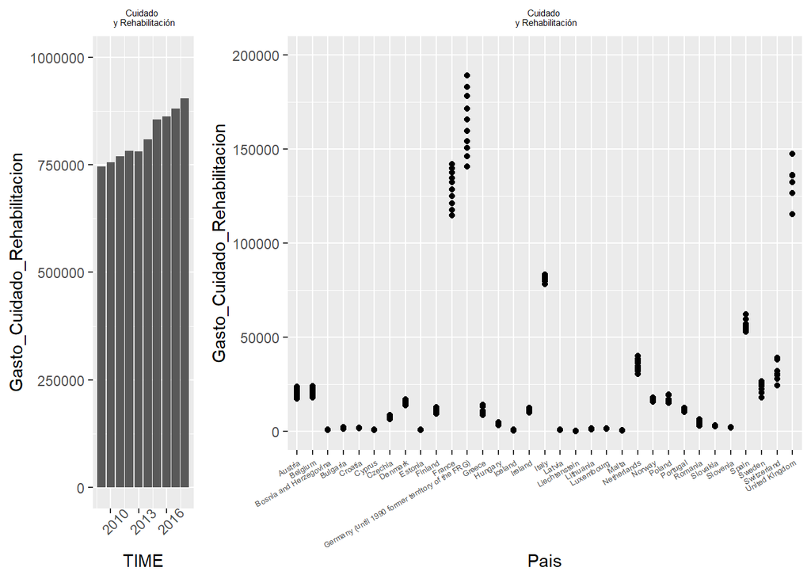

```r
#Gasto Sanitario Cuidado y Rehabilitación en general y en pacientes ingresados.
#=============================================================================

plot1=ggplot(data=gasto_df)+geom_col(aes(x=TIME,y=Gasto_Cuidado_Rehabilitacion))+
  theme(axis.text.x = element_text(angle = 45))+
  scale_y_continuous(limit=c(0,1000000))+
  ggtitle("Cuidado \n y Rehabilitación")+
  theme (plot.title = element_text(size=rel(0.5), hjust = 0.5))


plot2=ggplot(data=gasto_df)+geom_col(aes(x=TIME,y=Gasto_Cuidado_Rehabilitacion_Ingresados))+
  theme(axis.text.x = element_text(size= 5,angle = 30,vjust=1,hjust = 1))+
  scale_y_continuous(limit=c(0,1000000))+
  ggtitle("Cuidado \n y Rehabilitación \n Pacientes Ingresados")+
  theme (plot.title = element_text(size=rel(0.5),hjust = 0.5))


plot3=ggplot(data=gasto_df)+geom_point(aes(x=Pais,y=Gasto_Cuidado_Rehabilitacion))+
  theme(axis.text.x = element_text(size= 5,angle = 30,vjust=1,hjust = 1))+
  scale_y_continuous(limit=c(0,200000))+
  ggtitle("Cuidado \n y Rehabilitación")+
  theme (plot.title = element_text(size=rel(0.5),hjust=0.5))

plot4=ggplot(data=gasto_df)+geom_point(aes(x=Pais,y=Gasto_Cuidado_Rehabilitacion_Ingresados))+
  theme(axis.text.x = element_text(size= 5,angle = 30,vjust=1,hjust = 1))+
  scale_y_continuous(limit=c(0,200000))+
  ggtitle("Cuidado \n y Rehabilitación \n Pacientes Ingresados")+
  theme (plot.title = element_text(size=rel(0.5),hjust = 0.5))

grid.arrange(plot1,plot3,widths=c(1,3), ncol=2)
```

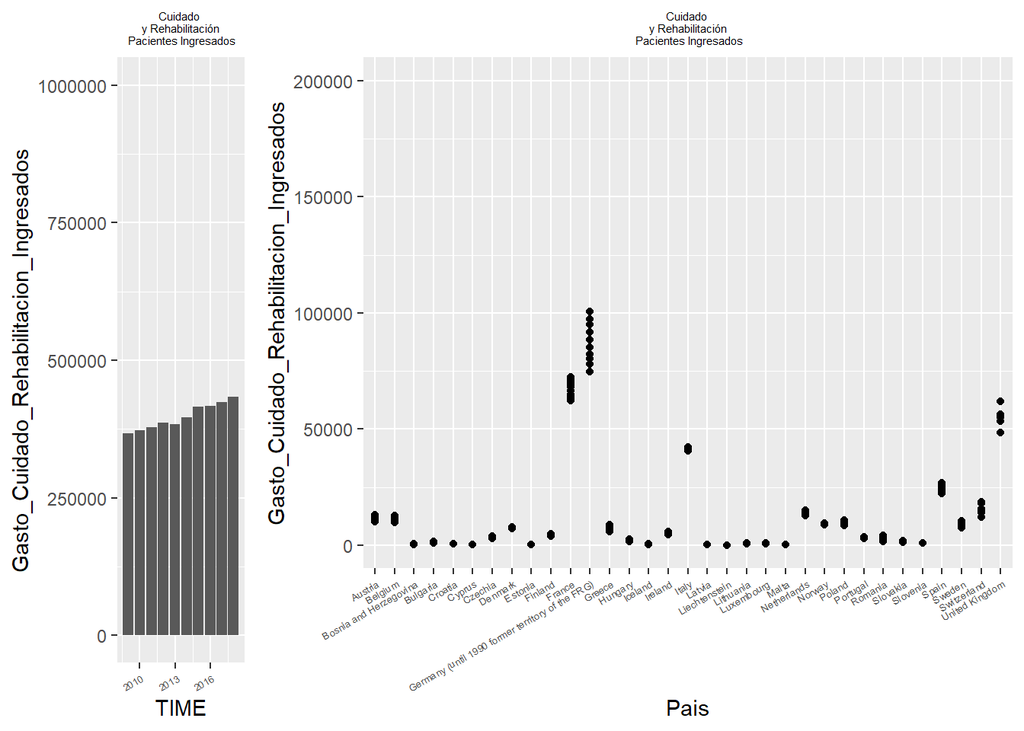

```r
grid.arrange(plot2,plot4,widths=c(1,3), ncol=2)
```

Se grafica la información de la variable “Value” en función de TIME, y el gasto Sanitario en Hospitales, Hospitales Mentales y Hospitales Especiales.

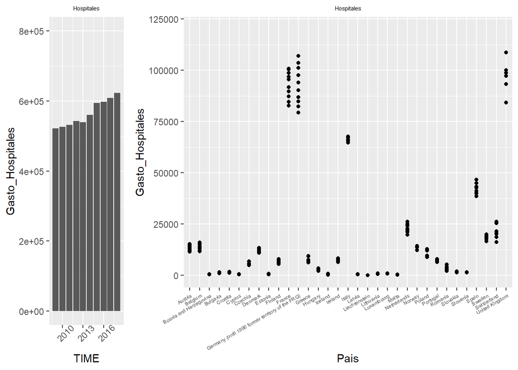

```r
#Gasto Sanitario en Hospitales, Hospitales Mentales y Hospitales Especiales.
#=============================================================================
plot1=ggplot(data=gasto_df)+geom_col(aes(x=TIME,y=Gasto_Hospitales))+
  theme(axis.text.x = element_text(angle = 45))+
  scale_y_continuous(limit=c(0,800000))+
  ggtitle("Hospitales")+
  theme (plot.title = element_text(size=rel(0.5), hjust = 0.5))

plot2=ggplot(data=gasto_df)+geom_col(aes(x=TIME,y=Gasto_Hospitales_Mentales))+
  theme(axis.text.x = element_text(size= 5,angle = 30,vjust=1,hjust = 1))+
  scale_y_continuous(limit=c(0,800000))+
  ggtitle("Hospitales \n y Mentales")+
  theme (plot.title = element_text(size=rel(0.5),hjust = 0.5))

plot3=ggplot(data=gasto_df)+geom_col(aes(x=TIME,y=Gasto_Hospitales_Especiales))+
  theme(axis.text.x = element_text(size= 5,angle = 30,vjust=1,hjust = 1))+
  scale_y_continuous(limit=c(0,800000))+
  ggtitle("Hospitales \n Especiales")+
  theme (plot.title = element_text(size=rel(0.5),hjust = 0.5))


plot4=ggplot(data=gasto_df)+geom_point(aes(x=Pais,y=Gasto_Hospitales))+
  theme(axis.text.x = element_text(size= 5,angle = 30,vjust=1,hjust = 1))+
  scale_y_continuous(limit=c(0,120000))+
  ggtitle("Hospitales")+
  theme (plot.title = element_text(size=rel(0.5),hjust=0.5))

plot5=ggplot(data=gasto_df)+geom_point(aes(x=Pais,y=Gasto_Hospitales_Mentales))+
  theme(axis.text.x = element_text(size= 5,angle = 30,vjust=1,hjust = 1))+
  scale_y_continuous(limit=c(0,120000))+
  ggtitle("Hospitales \n Mentales")+
  theme (plot.title = element_text(size=rel(0.5),hjust = 0.5))

plot6=ggplot(data=gasto_df)+geom_point(aes(x=Pais,y=Gasto_Hospitales_Especiales))+
  theme(axis.text.x = element_text(size= 5,angle = 30,vjust=1,hjust = 1))+
  scale_y_continuous(limit=c(0,120000))+
  ggtitle("Hospitales \n Especiales")+
  theme (plot.title = element_text(size=rel(0.5),hjust = 0.5))

grid.arrange(plot1,plot4,widths=c(1,3), ncol=2)
```

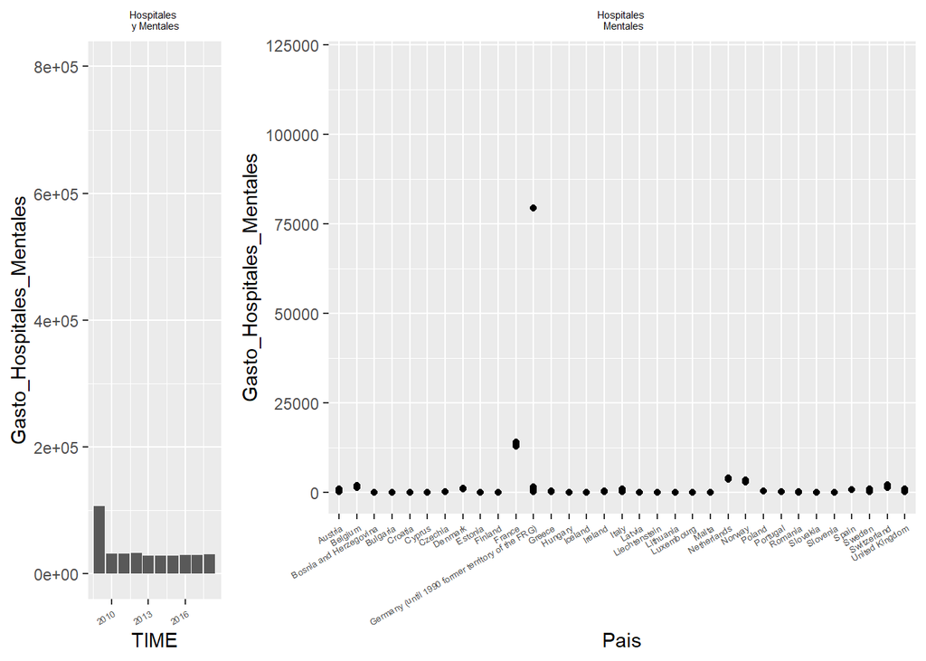

```r
grid.arrange(plot2,plot5,widths=c(1,3), ncol=2)
```

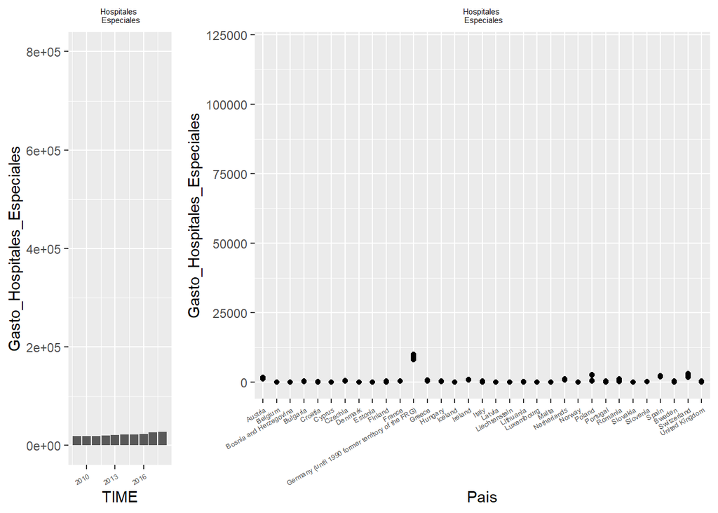

```r
grid.arrange(plot3,plot6,widths=c(1,3), ncol=2)
```

Se muestra la distribución de la variable “Value” en relación con la Financiación.

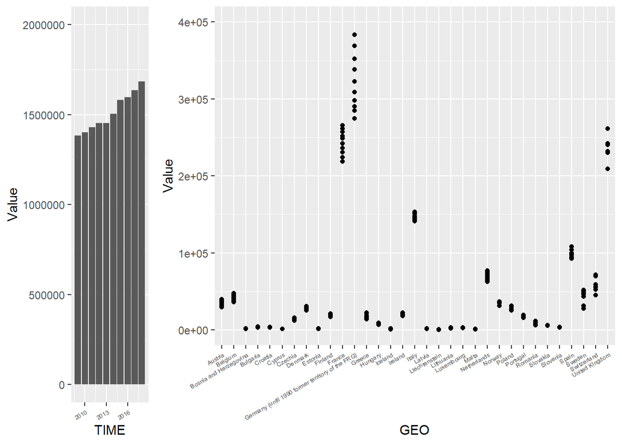

```r
plot5=ggplot(data=gasto_fin_paises)+geom_col(aes(x=TIME,y=Value))+
  theme(axis.text.x = element_text(size= 5,angle = 30,vjust=1,hjust = 1))+
    scale_y_continuous(limit=c(0,2000000))

plot6=ggplot(data=gasto_fin_paises)+geom_point(aes(x=GEO,y=Value))+
  theme(axis.text.x = element_text(size= 5,angle = 30,vjust=1,hjust = 1))+
   scale_y_continuous(limit=c(0,400000))

grid.arrange(plot5,plot6,widths=c(1,3), ncol=2)
```

A continuación, se muestra la distribución de Value en cómputo global (años y paises) para cada gasto aplicado:

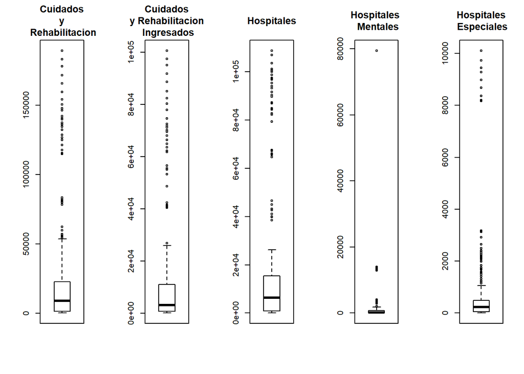

```r
par(mfrow=c(1,5))
boxplot(gasto_df$Gasto_Cuidado_Rehabilitacion,main="Cuidados\n y \n Rehabilitacion")
boxplot(gasto_df$Gasto_Cuidado_Rehabilitacion_Ingresados,main="Cuidados\n y Rehabilitacion \n Ingresados")
boxplot(gasto_df$Gasto_Hospitales,main="Hospitales")
boxplot(gasto_df$Gasto_Hospitales_Mentales,main="Hospitales \n Mentales")
boxplot(gasto_df$Gasto_Hospitales_Especiales,main="Hospitales\n Especiales")
```

```r
y_2009<-filter(gasto_fin_paises, TIME==2009)#Se filtra por Año
y_2010<-filter(gasto_fin_paises, TIME==2010)
y_2011<-filter(gasto_fin_paises, TIME==2011)
y_2012<-filter(gasto_fin_paises, TIME==2012)
y_2013<-filter(gasto_fin_paises, TIME==2013)
y_2014<-filter(gasto_fin_paises, TIME==2014)
y_2015<-filter(gasto_fin_paises, TIME==2015)
y_2016<-filter(gasto_fin_paises, TIME==2016)
y_2017<-filter(gasto_fin_paises, TIME==2017)
y_2018<-filter(gasto_fin_paises, TIME==2018)


gasto_fin_5paises_2009<-y_2009[with(y_2009, order(-y_2009$Value )),]#Se ordena por Value
gasto_fin_5paises_2010<-y_2010[with(y_2010, order(-y_2010$Value )),]
gasto_fin_5paises_2011<-y_2011[with(y_2011, order(-y_2011$Value )),]
gasto_fin_5paises_2012<-y_2012[with(y_2012, order(-y_2012$Value )),]
gasto_fin_5paises_2013<-y_2013[with(y_2013, order(-y_2013$Value )),]
gasto_fin_5paises_2014<-y_2014[with(y_2014, order(-y_2014$Value )),]
gasto_fin_5paises_2015<-y_2015[with(y_2015, order(-y_2015$Value )),]
gasto_fin_5paises_2016<-y_2016[with(y_2016, order(-y_2016$Value )),]
gasto_fin_5paises_2017<-y_2017[with(y_2017, order(-y_2017$Value )),]
gasto_fin_5paises_2018<-y_2018[with(y_2018, order(-y_2018$Value )),]

#Se crea una tabla para cada año sobre la Financiación de los 5 Paises un valor más alto.
kable(gasto_fin_5paises_2009[0:5,c(2,5)], col.names = c("País","Financiacion"), caption = "Países con mayor financiación en 2009")
```

Países con mayor financiación en 2009

|  | País | Financiacion |
| --- | --- | --- |
| 56 | Germany (until 1990 former territory of the FRG) | 274841.00 |
| 191 | United Kingdom | 229998.79 |
| 81 | France | 218751.88 |
| 91 | Italy | 142676.00 |
| 76 | Spain | 97384.01 |

```r
kable(gasto_fin_5paises_2010[0:5,c(2,5)], col.names = c("País","Financiacion"), caption = "Países con mayor financiación en 2010")
```

Países con mayor financiación en 2010

|  | País | Financiacion |
| --- | --- | --- |
| 256 | Germany (until 1990 former territory of the FRG) | 284568.00 |
| 391 | United Kingdom | 229998.79 |
| 281 | France | 224272.75 |
| 291 | Italy | 142676.00 |
| 276 | Spain | 97815.78 |

```r
kable(gasto_fin_5paises_2011[0:5,c(2,5)], col.names = c("País","Financiacion"), caption = "Países con mayor financiación en 2011")
```

Países con mayor financiación en 2011

|  | País | Financiacion |
| --- | --- | --- |
| 456 | Germany (until 1990 former territory of the FRG) | 290266.00 |
| 481 | France | 230575.03 |
| 591 | United Kingdom | 229998.79 |
| 491 | Italy | 142676.00 |
| 476 | Spain | 97532.09 |

```r
kable(gasto_fin_5paises_2012[0:5,c(2,5)], col.names = c("País","Financiacion"), caption = "Países con mayor financiación en 2012")
```

Países con mayor financiación en 2012

|  | País | Financiacion |
| --- | --- | --- |
| 656 | Germany (until 1990 former territory of the FRG) | 297784.00 |
| 681 | France | 236311.46 |
| 791 | United Kingdom | 229998.79 |
| 691 | Italy | 142676.00 |
| 676 | Spain | 94417.66 |

```r
kable(gasto_fin_5paises_2013[0:5,c(2,5)], col.names = c("País","Financiacion"), caption = "Países con mayor financiación en 2013")
```

Países con mayor financiación en 2013

|  | País | Financiacion |
| --- | --- | --- |
| 856 | Germany (until 1990 former territory of the FRG) | 309020.0 |
| 881 | France | 242123.4 |
| 991 | United Kingdom | 209392.5 |
| 891 | Italy | 141526.0 |
| 876 | Spain | 92518.8 |

```r
kable(gasto_fin_5paises_2014[0:5,c(2,5)], col.names = c("País","Financiacion"), caption = "Países con mayor financiación en 2014")
```

Países con mayor financiación en 2014

|  | País | Financiacion |
| --- | --- | --- |
| 1056 | Germany (until 1990 former territory of the FRG) | 322481.00 |
| 1081 | France | 248958.59 |
| 1191 | United Kingdom | 229998.79 |
| 1091 | Italy | 144317.00 |
| 1076 | Spain | 93824.25 |

```r
kable(gasto_fin_5paises_2015[0:5,c(2,5)], col.names = c("País","Financiacion"), caption = "Países con mayor financiación en 2015")
```

Países con mayor financiación en 2015

|  | País | Financiacion |
| --- | --- | --- |
| 1256 | Germany (until 1990 former territory of the FRG) | 338267.00 |
| 1391 | United Kingdom | 261567.48 |
| 1281 | France | 252075.88 |
| 1291 | Italy | 146613.00 |
| 1276 | Spain | 98350.22 |

```r
kable(gasto_fin_5paises_2016[0:5,c(2,5)], col.names = c("País","Financiacion"), caption = "Países con mayor financiación en 2016")
```

Países con mayor financiación en 2016

|  | País | Financiacion |
| --- | --- | --- |
| 1456 | Germany (until 1990 former territory of the FRG) | 352045.00 |
| 1481 | France | 256954.86 |
| 1591 | United Kingdom | 240259.87 |
| 1491 | Italy | 147963.00 |
| 1476 | Spain | 99715.25 |

```r
kable(gasto_fin_5paises_2017[0:5,c(2,5)], col.names = c("País","Financiacion"), caption = "Países con mayor financiación en 2017")
```

Países con mayor financiación en 2017

|  | País | Financiacion |
| --- | --- | --- |
| 1656 | Germany (until 1990 former territory of the FRG) | 369091.0 |
| 1681 | France | 261667.4 |
| 1791 | United Kingdom | 232178.1 |
| 1691 | Italy | 150697.0 |
| 1676 | Spain | 103899.9 |

```r
kable(gasto_fin_5paises_2018[0:5,c(2,5)], col.names = c("País","Financiacion"), caption = "Países con mayor financiación en 2018")
```

Países con mayor financiación en 2018

|  | País | Financiacion |
| --- | --- | --- |
| 1856 | Germany (until 1990 former territory of the FRG) | 383636.0 |
| 1881 | France | 265763.7 |
| 1991 | United Kingdom | 242300.0 |
| 1891 | Italy | 153085.0 |
| 1876 | Spain | 108109.7 |

A continuación, se aprupa toda la financiación por paises y se crea una tabla con toda la información:

```r
a1<-group_by(gasto_fin_paises,GEO)#Se agrupa por paises
a2<-select(a1,TIME:GEO:Value)#Seleccionamos las variables GEO y Value
a3<-(summarize(a2,suma=sum(Value)))#Se muestra la información por cada país, con Value=suma de los valores de cada país en los 10 años.
a4<-data.frame(a3)#Se convierte la información en un dataframe
a5<-a4[with(a4,order(-a4$suma)),]#Se ordena el DataFrame por la variable Suma de forma descendente.

#Se crea una tabla con toda la informacion
kable(a5[0:5,c(1,2)], col.names = c("País","Financiacion_MIllones de Euros"), caption = "Países con mayor financiación en 2009-2018")
```

Países con mayor financiación en 2009-2018

|  | País | Financiacion_MIllones de Euros |
| --- | --- | --- |
| 12 | Germany (until 1990 former territory of the FRG) | 3221999.0 |
| 11 | France | 2437454.9 |
| 33 | United Kingdom | 2335692.0 |
| 17 | Italy | 1454905.0 |
| 30 | Spain | 983567.6 |

- **1.1.3 Normalidad de la variable “Value”**

Se comprueba con métodos visuales si la variable tiene una distribución normal.

**FINANCIACION**

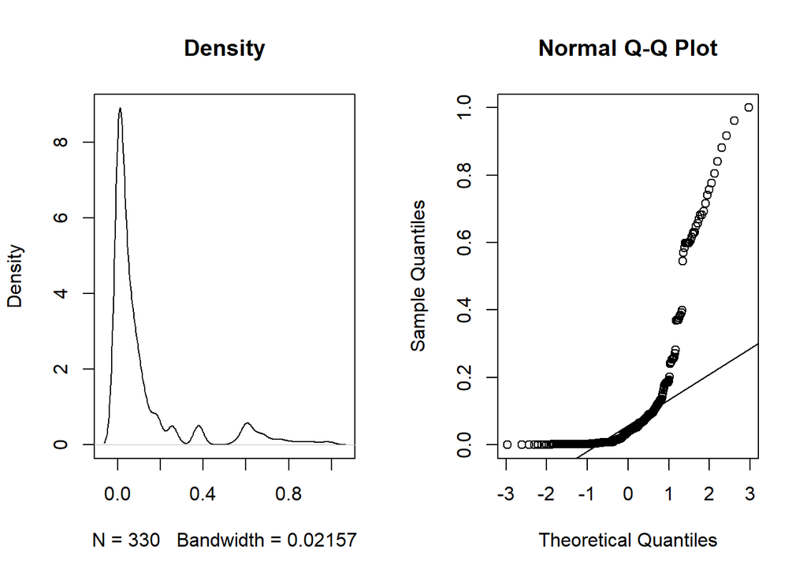

```r
par(mfrow=c(1,2))
plot(density(gasto_fin_paises$Value_norm_fin) ,main="Density")
qqnorm(gasto_fin_paises$Value_norm_fin)
qqline(gasto_fin_paises$Value_norm_fin)
```

Para estudiar si una muestra proviene de una población con distribución normal, se disponen de tres herramientas:

- Histograma o Densidad
- Gráficos cuantil cuantil (QQplot)
- Pruebas de hipótesis.